## COMP 5003 Assignment 2 - Final report

## Group 13

### 1. Overview of the problem

Hypoxemia is when someone is not carrying enough oxygen in their blood. It is a serious medical concern which can arise in various circumstances. Because of this hospitals are constantly measuring blood oxygen saturation. There are two ways of doing this, blood gas analysis (BGA) requires taking blood but is the gold standard of accuracy, and pulse oximetry which is more convenient but can be less accurate. The value measured by BGA is called SaO2, the value measured by oximetry is called SpO2. Pulse oximetry is what is used for continuous observation but because of its lesser accuracy, it can sometimes fail to pick up hypoxemia which would be revealed by BGA. We call this hidden hypoxemia and it can pose a serious threat to patients if it stops them from getting appropriate care.

We want to use machine learning classification on data from pulse oximetry and other common medical tests to find those who warrant further testing via BGA. This means both predicting hidden hypoxemia and finding the features important in making these predictions. Given the severe consequences of failing to detect hidden hypoxemia the recall of the tests is vitally important. At the same time it is resource-intensive to do too much BGA so recall needs to be balanced against precision.

### 2. Data Preprocessing

Data was sourced from MIMIC-IV (v2.2), a publicly available dataset of de-identified EHR data from50,920 unique patients at Beth lsrael Deaconess Medical Center, in Boston, MA, between 2008 -2019 [6,7]. The dataset includes a variety of patient information, treatment details, physiological measurements, and vital signs.

This dataset originally contained 81797 rows and 136 columns, with 36 numeric columns, 86 integer columns, 12 character columns and 2 logical columns. The response variable is “hidden_hypoxemia”, which is a binary variable, where 1 means the patient has hidden hypoxemia and 0 means they do not. Hidden hypoxemia occurs when SaO2 is below 88 and SpO2 is above 88 meaning the peripheral measure did not detect hypoxemia but the patient is suffering from it.

```r
suppressPackageStartupMessages({
  library(DT)
  library(knitr)
  library(caret)
  library(tidyverse)
  library(lightgbm)
  library(xgboost)
  library(randomForest)
  library(glmnet)
  library(stats)
  library(ranger)
  library(smotefamily)
  library(catboost)
  library(doParallel)
  library(PRROC)
  library(gridExtra)
  library(kableExtra)
})
set.seed(5003)
data <- read.csv("D:/Users/HP/Desktop/file/5003/pulseOx_data.csv")
data_use <- data %>% select(-X, -SaO2, -heart_rhythm)
partition <- createDataPartition(data_use$hidden_hypoxemia, p = 0.8, list = FALSE)
train_data <- data_use[partition, ]
test_data <- data_use[-partition, ]
```

Although we have eliminated variables with more than 60% values missing in the IDA part, there are still variables with lots of missing values. As we can see from the graph below, the number can reach 15617 in the training dataset.

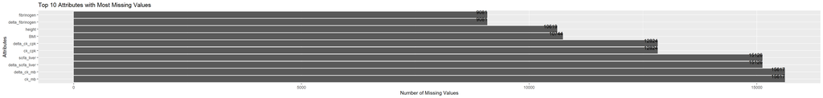

```r
# check missing value, draw bar chart of important variables
missing_values <- colSums(is.na(train_data))
missing_df <- data.frame(column = names(missing_values), missing_count = as.vector(missing_values))
# finding the top ten columns with missing values
top_missing_cols <- names(sort(missing_values, decreasing = TRUE)[1:10])
top_missing_df <- data.frame(column = names(missing_values), missing_count = as.vector(missing_values))
top_missing_df <- top_missing_df[order(-top_missing_df$missing_count), ][1:10, ]
# draw bar chart
ggplot(top_missing_df, aes(x = reorder(column, -missing_count), y = missing_count)) + geom_bar(stat = "identity") + geom_text(aes(label = missing_count), position = position_dodge(width = 0.9), vjust = -0.25, hjust = 1)+ coord_flip() + labs(title = "Top 10 Attributes with Most Missing Values", x = "Attributes", y = "Number of Missing Values")
```

We utilised 2 distinct methods for handling missing values in our dataset. For the variables Weight, Height and BMI we used the mean value for both methods. In Method 1, we impute other missing values using the median of a normal range for a healthy human. For Method 2, we generated a uniform distribution matching a healthy human and used this to impute the remaining missing values following (Matos, 2023). To prevent information leakage we ensured that if the test set needed imputation we used values from the training set. These methods are based on the assumption that if a patient does not have a test performed it is because they do not need it and the value is in a normal human range.

```r
# impute with median value
missing_value_1 <- function(data, mean_value = NULL){

  #use the mean of the training dataset to impute the missing value in the test dataset
  if (is.null(mean_value) == T){
      data$weight[is.na(data$weight)] <- mean(data$weight, na.rm = TRUE)
      data$height[is.na(data$height)] <- mean(data$height, na.rm = TRUE)
      data$BMI[is.na(data$BMI)] <- mean(data$BMI, na.rm = TRUE)
  } else {
      data$weight[is.na(data$weight)] <- mean_value[1]
      data$height[is.na(data$height)] <- mean_value[2]
      data$BMI[is.na(data$BMI)] <- mean_value[3]
  }


  data$sofa_liver[is.na(data$sofa_liver)] <- 0  #0 represents have no problem
  data$FiO2[is.na(data$FiO2)] <- 21 # standard
  data$sofa_resp[is.na(data$sofa_resp)] <- 0


  data$ck_mb[is.na(data$ck_mb)] <- 2.5  #0-5
  data$ck_cpk[data$gender == "F" & is.na(data$ck_cpk)] <- 109  #26 - 192
  data$ck_cpk[data$gender == "M" & is.na(data$ck_cpk)] <- 173.5 #39 - 308
  data$fibrinogen[is.na(data$fibrinogen)] <- 300 #200 - 400
  data$ld_ldh[is.na(data$ld_ldh)] <- 210    #140 - 280
  data$albumin[is.na(data$albumin)] <- 4.4  #3.4 - 5.4
  data$bilirubin_total[is.na(data$bilirubin_total)] <- 0.65   #0.1 - 1.2
  data$alp[is.na(data$alp)] <- 95.5  #44 - 147
  data$alt[is.na(data$alt)] <- 31.5      #7 - 56
  data$ast[is.na(data$ast)] <- 25      #10 - 40
  data$calcium[is.na(data$calcium)] <- 9.8  #8.5 - 10.5
  data$temperature[is.na(data$temperature)] <- 36.65   #36.1 - 37.2
  data$lactate[is.na(data$lactate)] <- 1.05   #0.5 - 1.6

  # Fill NA values in columns starting with "delta" with 0
  delta_columns <- grep("^delta", names(data), value = TRUE)
  data[, delta_columns] <- lapply(data[, delta_columns], function(col) ifelse(is.na(col), 0, col))

  # Drop rows with NA values
  remove_list <<- complete.cases(data)
  data_dropna <- data[complete.cases(data), ]
  return(data_dropna)
}
```

```r
# impute with uniform distribution
missing_value_2 <- function(data, mean_value = NULL){
  #use the mean of the training dataset to impute the missing value in the test dataset
  if (is.null(mean_value) == T){
      data$weight[is.na(data$weight)] <- mean(data$weight, na.rm = TRUE)
      data$height[is.na(data$height)] <- mean(data$height, na.rm = TRUE)
      data$BMI[is.na(data$BMI)] <- mean(data$BMI, na.rm = TRUE)
  } else {
      data$weight[is.na(data$weight)] <- mean_value[1]
      data$height[is.na(data$height)] <- mean_value[2]
      data$BMI[is.na(data$BMI)] <- mean_value[3]
  }

  data$sofa_liver[is.na(data$sofa_liver)] <- 0  #0 represents have no problem
  data$FiO2[is.na(data$FiO2)] <- 21 # standard
  data$sofa_resp[is.na(data$sofa_resp)] <- 0

  set.seed(5003)
  data$ck_mb[is.na(data$ck_mb)] <- runif(sum(is.na(data$ck_mb)), 0, 5)

  female_na <- data$gender == "F" & is.na(data$ck_cpk)
  male_na <- data$gender == "M" & is.na(data$ck_cpk)
  data$ck_cpk[female_na] <- runif(sum(female_na), 26, 192)
  data$ck_cpk[male_na] <- runif(sum(male_na), 39, 308)

  data$fibrinogen[is.na(data$fibrinogen)] <- runif(sum(is.na(data$fibrinogen)), 200, 400)
  data$ld_ldh[is.na(data$ld_ldh)] <- runif(sum(is.na(data$ld_ldh)), 140, 280)
  data$albumin[is.na(data$albumin)] <- runif(sum(is.na(data$albumin)), 3.4, 5.4)
  data$bilirubin_total[is.na(data$bilirubin_total)] <- runif(sum(is.na(data$bilirubin_total)), 0.1, 1.2)
  data$alp[is.na(data$alp)] <- runif(sum(is.na(data$alp)), 44, 147)
  data$alt[is.na(data$alt)] <- runif(sum(is.na(data$alt)), 7, 56)
  data$ast[is.na(data$ast)] <- runif(sum(is.na(data$ast)), 10, 40)
  data$calcium[is.na(data$calcium)] <- runif(sum(is.na(data$calcium)), 8.5, 10.5)
  data$temperature[is.na(data$temperature)] <- runif(sum(is.na(data$temperature)), 36.1, 37.2)
  data$lactate[is.na(data$lactate)] <- runif(sum(is.na(data$lactate)), 0.5, 1.6)

  # Fill NA values in columns starting with "delta" with 0
  delta_columns <- grep("^delta", names(data), value = TRUE)
  data[, delta_columns] <- lapply(data[, delta_columns], function(col) ifelse(is.na(col), 0, col))

  # Drop rows with NA values
  data_dropna <- data[complete.cases(data), ]
  return(data_dropna)
}
```

```r
# no imputation. only for boosting models.
missing_value_3 <- function(data, mean_value = NULL){
  return(data)
}
```

Here, we choose MinMax scaling to normalize the subsequent KNN, SVM, and LR, so that during computation they won’t be overly influenced by certain features, and it can also speed up convergence. For the subsequent tree models, we do not perform normalization because, unlike distance-based models like KNN or SVM, tree models split data by selecting a feature and setting a threshold, unaffected by the scale of the feature. At the same time, we use the minimum and maximum values from the training set to standardize the test set to prevent data leakage.

```r
minmax_scale <- function(x, min_val = NULL, max_val = NULL) {
  if (is.null(min_val))
    min_val <- min(x, na.rm = TRUE)
  if (is.null(max_val))
    max_val <- max(x, na.rm = TRUE)
  if (max_val - min_val == 0)
    return(rep(0, length(x)))
  return ((x - min_val) / (max_val - min_val))
}

minmax_scale_df <- function(data, train_data = NULL) {
  # Check if we're scaling based on training data
  if (!is.null(train_data)) {
    min_vals <- sapply(train_data, min)
    max_vals <- sapply(train_data, max)
  } else {
    min_vals <- sapply(data, min)
    max_vals <- sapply(data, max)
  }

  data <- mapply(minmax_scale, data, min_vals, max_vals, SIMPLIFY = FALSE)

  return(data)
}
```

Information loss could result from method 1, and an increase in false positive samples could come from method 2. To determine which approach is best for each model, two approaches are applied in each model.

```r
balance_method_1 <- function(data){
  set.seed(5003)
  data <- data %>% select(-subject_id)
  data_1 <- data %>% filter(hidden_hypoxemia == 1)
  data_0_sample <- data %>% filter(hidden_hypoxemia == 0) %>% sample_n(nrow(data_1))
  balanced_data <- rbind(data_1, data_0_sample)
  return(balanced_data)
}

balance_method_2 <- function(data){
  set.seed(5003)
  multi <- 5
  data <- data %>% select(-subject_id)
  data_1 <- data %>% filter(hidden_hypoxemia == 1)
  data_1 <- SMOTE(data_1[, -which(names(data_1) == "hidden_hypoxemia")], data_1$hidden_hypoxemia, K = multi, dup_size = multi)$data
  names(data_1)[ncol(data_1)] <- "hidden_hypoxemia"
  data_1[,ncol(data_1)] <- as.numeric(data_1[,ncol(data_1)])
  data_0_sample <- data %>% filter(hidden_hypoxemia == 0) %>% sample_n(nrow(data_1))
  balanced_data <- rbind(data_1, data_0_sample)
  return(balanced_data)
}
```

Machine learning algorithms like SVM do not inherently support categorical data thus one-hot encoding, a technique to transform categorical data into a format that can be provided to machine learning algorithms for better performance and interpretability was applied.

```r
one_hot_encode_all_caret <- function(df) {
  dv <- dummyVars("~ .", data = df)
  df_encoded <- data.frame(predict(dv, newdata = df))
  return(df_encoded)
}
```

As we are dealing with a high-dimensional dataset, we decided to do some feature selection using lasso regression and principal component analysis (PCA).

Lasso regression is a regularization technique that effectively shrinks certain coefficients to zero. After extracting the target variable hidden_hypoxemia, Lasso regression was applied, accompanied by cross-validation. Instead of selecting the optimal regularization strength, we used the default value for λ. This process ensures that only features with non-zero coefficients are retained. To avoid complexity, if the total number of these selected features surpasses a predetermined threshold (set to 50 in our code), only the top 50 features, sorted by the absolute magnitude of their coefficients, are preserved. As a result, our refined datasets for training and testing consist of these essential features, alongside the original target variable.

```
## The top five features selected by Lasso are: delta_ptt, delta_lactate, delta_inr, ph, alt
```

Principal Component Analysis (PCA) serves as a powerful technique for reducing data dimensionality while striving to retain as much variance as possible from the original dataset. In our methodology, we first exclude the target ‘hidden_hypoxemia’ and proceed to eliminate features with zero variance. Following this, PCA is applied to the data that has been both centered and scaled. Our selection criterion for principal components is based on capturing a minimum of 90% of the initial data variance. This approach yields training and testing datasets enriched with these significant components, in addition to the original target. From the plot, the 63st principal component emerges as a crucial threshold, accounting for 90% of the cumulative variance. In the plot, under the conditions where the first method for missing value handling and sampling are chosen, as an example, the 63rd principal component emerges as a crucial threshold, accounting for 90% of the cumulative variance. Subsequent changes in processing methods might alter the number of variables, depending specifically on the combination of preprocessing techniques used.

```r
pca_feature_selection <- function(train_data, test_data) {

  response_train <- train_data$hidden_hypoxemia
  predictors_train <- train_data %>% select(-hidden_hypoxemia)

  pca_result <- prcomp(predictors_train, center = TRUE, scale. = TRUE)
  explained_variance <- summary(pca_result)$importance[2,]
  cumulative_variance <- cumsum(explained_variance)
  num_features <- which(cumulative_variance >= 0.90)[1]

  pca_scores_train <- pca_result$x[, 1:num_features]
  transformed_train <- cbind(pca_scores_train, "hidden_hypoxemia" = response_train)

  # Transform the test data using the PCA model from the training data
  predictors_test <- test_data %>% select(-hidden_hypoxemia)
  pca_scores_test <- predict(pca_result, newdata = predictors_test)[, 1:num_features]
  response_test <- test_data$hidden_hypoxemia
  transformed_test <- cbind(pca_scores_test, "hidden_hypoxemia" = response_test)

  return(list(train_data = transformed_train, test_data = transformed_test))
}
```

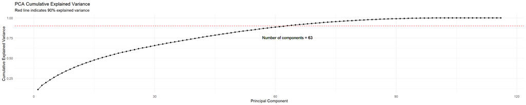

```r
data_pca_temp <- train_data %>% one_hot_encode_all_caret() %>% missing_value_1() %>% balance_method_1() %>% minmax_scale_df() %>% data.frame()
pca_result <- prcomp(data_pca_temp, center = TRUE, scale. = TRUE)

# Calculate explained variance
explained_variance <- pca_result$sdev^2 / sum(pca_result$sdev^2)
cumulative_explained_variance <- cumsum(explained_variance)
num_components <- which.max(cumulative_explained_variance > 0.9)

# Plot
ggplot(data.frame(Components = 1:length(explained_variance), Cumulative_Variance = cumulative_explained_variance), aes(x = Components, y = Cumulative_Variance)) +
  geom_line() +
  geom_point() +
  geom_hline(yintercept = 0.9, linetype="dashed", color="red") +
  geom_text(aes(x = num_components, y = 0.7), label = paste("Number of components =", num_components), vjust = -1) +
  labs(title = "PCA Cumulative Explained Variance",
       subtitle = "Red line indicates 90% explained variance",
       x = "Principal Component",
       y = "Cumulative Explained Variance") +
  theme_minimal()
```

```r
loadings_first_pc <- pca_result$rotation[, 1]

# Identify the variable with the highest absolute loading in the first principal component
max_loading_variable <- names(loadings_first_pc)[which.max(abs(loadings_first_pc))]

# Print out the most influential variable
cat("The most influential variable in the first principal component is:", max_loading_variable, "\n")
```

```
## The most influential variable in the first principal component is: delta_rdw
```

```r
# No feature engineering
no_feature_selection <- function(train_data, test_data) {
  return(list(train_data = train_data, test_data = test_data))
}
```

### 3. Classification Method

To tackle this classification problem, we trained 7 different machine learning algorithms on our dataset that can be broadly split up into 2 groups.

#### Baseline Models

The first group we dub the “Baseline Methods” which consist of K-Nearest Neighbours (KNN), Support Vector Machine (SVM) and Logistic Regression.

*KNN*: KNN has proven to be more effective than a text feature selection algorithm based on the Gini index in the medical health big Data Classification task(Xing and Bei, 2020). Given that KNN can handle both continuous and categorical variables and operates without any underlying assumptions about the distribution of the data, it may be appropriate for this dataset which contains multivariate features.

*SVM*: Data mining, pattern recognition, and machine learning communities have been interested in SVM recently due to its exceptional generalisation ability, optimal solution, and discriminative power (Cervantes et al., 2020). SVM can efficiently manage the high-dimensional space of our data and works well for both linear and non-linear datasets. However, SVMs can be sensitive to class imbalance, a challenge that can be mitigated through techniques mentioned before. To determine whether our data is linearly separable, we built an SVM model using a linear kernel because Polynomial SVM and RBF would require a lot of processing power with a huge dataset, which we cannot afford.

*LR*: Logistic Regression can handle both continuous and categorical data features while forecasting binary outcomes. It has shown great performance in early and accurate diagnosis of myocardial infarction in patients who present to the Emergency Room complaining of chest pain with 94.28% and 94.30% of ROC curve area (Tsien et al., 1998). We adapted a logistic regression model using glmnet method, which supports both Lasso and Ridge regularization as well as combinations in between. It’s effectiveness might be compromised due to the presence of imbalances in the data and multicollinearity among the features however by adjusting the regression decision threshold to cater to the imbalance and applying PCA to reduce dimensionality and ensure feature independence we can help satisfy the model assumptions and potentially enhance performance.

The parameter tuning for the base-line model is supported by (Probst, Wright, & Boulesteix, 2019), and we use the recall as the criteria to choose the parameters since recall specifies the ability to successfully predict the hidden hypoxemia. In addition, as our data is imbalanced and highly dimensional we do not expect these Baseline methods to be particularly useful in this problem. We intend to use them as a benchmark to compare against our other group of algorithms; the Tree models.

#### Tree-based Models

Beyond these we used four tree based models: Random Forest, XGBoost, LightGBM and CatBoost. They do not require the data to meet strict distribution assumptions, making them flexible. They have essentially built in feature selection. They have a strong ability to handle missing values, unbalanced data and potential overfitting achieved through various built-in mechanisms and strategies. The final three are also boosting models helping them to build strong classifiers from weak ones which is very useful on challenging data like ours. We used cross validation to tune the hyperparameters of these models.We expect these tree models to perform better than the first three.

*RF*: Random Forest is a tree-based method used for both classification and regression without assuming prior relationships between predictors and the response. It’s known for its robustness and accuracy, as demonstrated in studies on hepatitis and breast cancer datasets(Alam, Rahman and Rahman, 2019). Key parameters include the structure of each tree, where we determined the optimal minimum node size to be 10, the size of the forest, with our choice being 500 trees for efficiency, and the randomness, where the optimal number of candidate variables for each split, mtry, was found to be 17 for our data.

*XGBoost*: One of the most performant and scalable ensemble methods making it a prime candidate for this classification problem (Chen and Guestrin, 2016). It is proven that XGBoost outperformed other well-known classification methods in biological data (Dimitrakopoulos et al., 2018). The key hyperparameters for an XGboost model are learning rate, max depth and gamma. We tuned the learning rate of our model, finding a moderate learning rate of 0.5 yielded the best results. We also needed to tune the depth or complexity of our tree, finding in contrast to CatBoost that a larger tree with a depth of 12 yielded the greatest accuracy. Gamma or the minimum loss reduction required for a leaf node, is a regularisation parameter used to prevent overfitting and minimise complexity. We find a moderate value of 0.3 is best.

*LightGBM*: LightGBM has been found to be powerful when identifying and classifying miRNA in breast cancer (Wang, Zhang and Zhao, 2017). After converting data into a format suitable for LightGBM, it is trained by establishing prefined hyerparameters like learning rate , number of leaves and feature selection. The learning rate determines the adjustment magnitude the model makes to errors in each iteration. Too high, and the model might overfit; too low, and more iterations might be needed. Tuning the learning rate is crucial for the model’s convergence speed and performance. The num_leaves parameter dictates the complexity of the model. More leaves allow the model to learn more intricate patterns but can also lead to overfitting. Choosing the right number of leaves balances the model’s fit and complexity. feature_selection involves randomly selecting a subset of features for training in each iteration, aiding in faster training and reducing the risk of overfitting. Selecting the appropriate feature sampling rate can enhance the robustness of the model.

*CatBoost*: A boosting ensemble method designed to be effective on data containing categorical variables of which our data has several. Performed best with undersampling and without feature selection resulting in only ~2000 samples but 107 features. Therefore we tuned tree depth in a moderately large range (3-8) to deal with complexity and we tuned L2 regularisation coefficient to deal with potential overfitting. The small number of samples led us to try tuning the randomness of splits via random_strength to increase generalisability but this did not produce any improvement.

To tune our models we used 5-fold cross-validation in a rigorous grid search to tune the hyperparameters of all our models. In conjunction with choosing our Missing Value, feature selection, and Balancing methods. This tuning resulted in impressive gains in specificity, sensitivity, and F1 scores.

```r
params_all <- read_csv("D:/Users/HP/Desktop/file/5003/just_best_params.csv",show_col_types = FALSE)

params_all <- kable(params_all, caption = "Models and their best hyperparamters")%>%
  kable_paper( html_font = "Cambria", position = "left")

params_all
```

Models and their best hyperparamters

[output not shown]

```r
train_knn_cv <- function(train_data) {
    train_data$hidden_hypoxemia <- as.factor(train_data$hidden_hypoxemia)
    best_params <- data.frame(k = 13)
    model <- train(hidden_hypoxemia ~ ., data = train_data, method = "knn", tuneGrid = best_params)
    return(list(model = model,
                best_params = best_params))
}

train_svm_cv <- function(train_data) {
    train_data$hidden_hypoxemia <- as.factor(train_data$hidden_hypoxemia)
    best_params <- data.frame(C = 0.01)
    model <- train(hidden_hypoxemia ~ ., data = train_data, method = "svmLinear", tuneGrid = best_params)
    return(list(model = model,
                best_params = best_params))
}

train_lr_cv <- function(train_data) {
    train_data$hidden_hypoxemia <- as.factor(train_data$hidden_hypoxemia)
    best_params <- data.frame(alpha = 0, lambda = 0.1)
    model <- train(hidden_hypoxemia ~ ., data = train_data, method = "glmnet", tuneGrid = best_params)

    return(list(model = model,
                best_params = best_params))
}

train_xgboost_cv <- function(train_data) {
    dtrain <- xgb.DMatrix(data = as.matrix(train_data[, -which(names(train_data) == "hidden_hypoxemia")]),
                          label = train_data$hidden_hypoxemia)
    best_params <- list(objective = "binary:logistic", eval_metric = "error", max_depth = 12 , learning_rate = 0.5, gamma = 0.3)
    model <- xgb.train(params = best_params, data = dtrain, nrounds = 100)
    return(list(model = model,
                best_params = best_params))
}

train_randomForest_cv <- function(train_data) {
    train_data$hidden_hypoxemia <- as.factor(train_data$hidden_hypoxemia)
    best_params <- data.frame(mtry = 17,splitrule = "gini",min.node.size = 10)
    control <- trainControl(method = "oob", number = 5, verboseIter = TRUE)
    model <- train(hidden_hypoxemia ~ ., data = train_data, method = "ranger", trControl = control, tuneGrid = best_params)
    return(list(model = model,
                best_params = model$bestTune))
}

train_catboost_cv <- function(train_data) {

      #Catboost uses factor and integer data.
      train_target=train_data$hidden_hypoxemia
      train_vars<<-select(train_data,-hidden_hypoxemia)
      train_vars<<-as.data.frame(lapply(train_vars, function(col) {
        if (is.character(col)) {
          return(as.factor(col))
        }
        return(col)
      }))
      #ensure target is integer
      train_target = as.integer(train_target)

      #Put data into a pool
      train_pool=catboost.load_pool(data=train_vars, label=train_target)

      cat_params=list(loss_function = 'Logloss',depth = 8, learning_rate = 0.02,iterations = 1000,
        verbose = 100, od_type = 'Iter', od_wait = 20, l2_leaf_reg = 5,task_type = 'GPU')

      #Get training and validation data for training model with appropriate parameters.
      val_split=createDataPartition(train_data$hidden_hypoxemia,p=0.8,list=FALSE)
      train_train=train_data[val_split,]
      train_val=train_data[-val_split,]

      val_target=train_val$hidden_hypoxemia
      val_vars=select(train_val,-hidden_hypoxemia)
      val_vars <- as.data.frame(lapply(val_vars, function(col) {
        if (is.character(col)) {
          return(as.factor(col))
        }
        return(col)
      }))
      val_target <- as.integer(val_target)
      val_vars$race <- factor(val_vars$race, levels = levels(train_vars$race))

      train_target=train_train$hidden_hypoxemia
      train_vars=select(train_train,-hidden_hypoxemia)
      train_vars <- as.data.frame(lapply(train_vars, function(col) {
        if (is.character(col)) {
          return(as.factor(col))
        }
        return(col)
      }))
      train_target <- as.integer(train_target)

      train_pool <<- catboost.load_pool(data = train_vars, label = train_target)
      eval_pool <- catboost.load_pool(data = val_vars, label = val_target)

      model <<- catboost.train(train_pool, params = cat_params, test_pool = eval_pool)

      return(list(model = model,
          best_params = cat_params,
          train_pool = train_pool
          ))
}

train_lightgbm_cv <- function(train_data) {
    dtrain <- lgb.Dataset(data = as.matrix(train_data[, -which(names(train_data) == "hidden_hypoxemia")]), label = train_data$hidden_hypoxemia)
    best_params <- best_params <- list(objective = "binary", metric = "binary_error", learning_rate=0.7, num_leaves=80, feature_fraction=1)
    model <- lgb.train(params = best_params, data = dtrain, obj = "binary")
    return(list(model = model,
                best_params = best_params))
}
```

```r
train_model <- function(train_data, model_type = "xgboost") {
  if (model_type == "xgboost")
    train_result = train_xgboost_cv(train_data)
  else if (model_type == "catboost")
    train_result = train_catboost_cv(train_data)
  else if (model_type == "lightgbm")
    train_result = train_lightgbm_cv(train_data)
  else if (model_type == "rf")
    train_result = train_randomForest_cv(train_data)
  else if (model_type == "knn")
    train_result = train_knn_cv(train_data)
  else if (model_type == "svm")
    train_result = train_svm_cv(train_data)
  else if (model_type == "lr")
    train_result = train_lr_cv(train_data)

  return(train_result)
}
```

```r
params_to_string <- function(params_list) {
    keys <- names(params_list)
    key_value_strings <- lapply(keys, function(key) {
        paste(key, ":", params_list[[key]])
    })
    params_str <- paste(key_value_strings, collapse = " | ")
    return(params_str)
}
```

```r
evaluate_model <- function(data_use, model_type = "xgboost", missing_method = missing_value_2,
                           balance_method = balance_method_1, feature_selection_method = lasso_feature_selection, threshold = 0.5) {
    set.seed(5003)
    confusion_matrices_train <- list()
    confusion_matrices_test <- list()
    best_params <- list()
    results_df <- data.frame("ID" = 1)
    cl <- makeCluster(detectCores()-4)
    registerDoParallel(cl)

    partition <- createDataPartition(data_use$hidden_hypoxemia, p = 0.8, list = FALSE)
    train_data <- data_use[partition, ]
    test_data <- data_use[-partition, ]

    if (model_type %in% c("knn", "svm", "lr")){
      balanced_data <- train_data %>% missing_method() %>% balance_method() %>% minmax_scale_df() %>% data.frame()
      test_fold <- test_data %>% select(-subject_id) %>%
        missing_method(mean_value = c(mean(balanced_data$weight), mean(balanced_data$height), mean(balanced_data$BMI))) %>%
        minmax_scale_df(balanced_data) %>% data.frame()
    } else {
      balanced_data <- train_data  %>% missing_method() %>% balance_method()
      test_fold <- test_data %>% select(-subject_id) %>%
        missing_method(mean_value = c(mean(balanced_data$weight), mean(balanced_data$height), mean(balanced_data$BMI)))
    }

    #feature selection
    feature_selection_result <- feature_selection_method(train_data = balanced_data, test_data = test_fold)
    balanced_data <- data.frame(feature_selection_result$train_data)
    test_fold <- data.frame(feature_selection_result$test_data)

    # Train model using the specified model type
    capture.output(  # hide the training output
        suppressWarnings({
            start_time <- Sys.time()
            train_result <- train_model(balanced_data, model_type)
            end_time <- Sys.time()
        }),
        file = NULL
    )

    #get the results of the training part
    model <- train_result$model
    best_params <- append(best_params, params_to_string(train_result$best_params))



    if (model_type %in% c("knn", "svm", "lr", "rf")){
      preds_train <- predict(model, as.matrix(balanced_data[, colnames(balanced_data[-which(names(balanced_data) == "hidden_hypoxemia")])]))
      preds_prob <- predict(model, newdata = as.matrix(test_fold[, colnames(test_fold[-which(names(test_fold) == "hidden_hypoxemia")])]))
      preds_test <- predict(model, newdata = as.matrix(test_fold[, colnames(test_fold[-which(names(test_fold) == "hidden_hypoxemia")])]))
    } else if (model_type %in% c("catboost")){
      test_target=test_fold$hidden_hypoxemia
      test_vars<<-select(test_fold,-hidden_hypoxemia)
      test_vars<<-as.data.frame(lapply(test_vars, function(col) {
        if (is.character(col)) {
          return(as.factor(col))
        }
        return(col)
      }))
      test_target = as.integer(test_target) # Assuming it's originally 0 and 1
      #Race was specifically a problem. Make sure it is the same in test and train data.
      test_vars$race<<-factor(test_vars$race, levels = levels(train_vars$race))
      test_pool = catboost.load_pool(data = test_vars, label = test_target)
      preds_prob = catboost.predict(model, test_pool)
      preds_test = ifelse(preds_prob >= threshold, 1, 0)
      train_target=balanced_data$hidden_hypoxemia
      train_vars<<-select(balanced_data,-hidden_hypoxemia)
      train_vars<<-as.data.frame(lapply(train_vars, function(col) {
        if (is.character(col)) {
          return(as.factor(col))
        }
        return(col)
      }))
      #ensure target is integer
      train_target = as.integer(train_target)
      train_vars$race<<-factor(train_vars$race, levels = levels(train_vars$race))
      train_pool = catboost.load_pool(data = train_vars, label = train_target)
      preds_train = catboost.predict(model, train_pool)
      preds_train = ifelse(preds_train >= threshold, 1, 0)

    } else {
      preds_prob <- predict(model, as.matrix(balanced_data[, colnames(balanced_data[-which(names(balanced_data) == "hidden_hypoxemia")])]))
      preds_train <- ifelse(preds_prob >= threshold, 1, 0)
      preds_prob <- predict(model, as.matrix(test_fold[, colnames(test_fold[-which(names(test_fold) == "hidden_hypoxemia")])]))
      preds_test <- ifelse(preds_prob >= threshold, 1, 0)
    }

    train_label = factor(balanced_data$hidden_hypoxemia, levels = c(1, 0))
    test_label = factor(test_fold$hidden_hypoxemia, levels = c(1, 0))
    preds_train = factor(preds_train, levels = c(1, 0))
    preds_test = factor(preds_test, levels = c(1, 0))

    confusion_mtx_train <- confusionMatrix(preds_train, train_label, mode="everything")
    confusion_matrices_train <- append(confusion_matrices_train, list(confusion_mtx_train))
    confusion_mtx_test <- confusionMatrix(preds_test, test_label, mode="everything")
    confusion_matrices_test <- append(confusion_matrices_test, list(confusion_mtx_test))

    stopCluster(cl)

    results_df$confusion_matrices_train <- confusion_matrices_train
    results_df$confusion_matrices_test <- confusion_matrices_test
    results_df$best_params <- best_params
    results_df$runtime <- end_time - start_time

    return(list(model = model,
                results = results_df,
                pred_prob = preds_prob,
                pred_test = preds_test,
                true_test = test_fold$hidden_hypoxemia))
}
```

```r
set.seed(5003)
data_final <- data_use %>% one_hot_encode_all_caret()
result_knn <- evaluate_model(data_final, model_type = "knn", missing_method = missing_value_2,
                             feature_selection_method = lasso_feature_selection,
                             balance_method = balance_method_1)
result_svm <- evaluate_model(data_final, model_type = "svm", missing_method = missing_value_1,
                            feature_selection_method = no_feature_selection,
                            balance_method = balance_method_1)
result_lr <- evaluate_model(data_final, model_type = "lr", missing_method = missing_value_1,
                            feature_selection_method = lasso_feature_selection,
                            balance_method = balance_method_1)
result_rf <- evaluate_model(data_final, model_type = "rf", missing_method = missing_value_1,
                            feature_selection_method = no_feature_selection,
                            balance_method = balance_method_1)
result_xb <- evaluate_model(data_final, model_type = "xgboost", missing_method = missing_value_3,
                            feature_selection_method = no_feature_selection,
                            balance_method = balance_method_1)
result_lgb <- evaluate_model(data_final, model_type = "lightgbm", missing_method = missing_value_3,
                             feature_selection_method = no_feature_selection,
                             balance_method = balance_method_1)
result_cb <- evaluate_model(data_use, model_type = "catboost", missing_method = missing_value_3,
                            feature_selection_method = no_feature_selection,
                            balance_method = balance_method_1)
```

```r
result_combine <- rbind(result_knn$results, result_svm$results, result_lr$results, result_rf$results,
                        result_xb$results, result_lgb$results, result_cb$results)
result_combine$ID = c("knn", "svm", "lr", "rf", "xgboost", "lightgbm", "catboost")
```

```r
process_results <- function(all_results) {

  parse_confusion_matrix <- function(cell) {
    list(
      Accuracy = cell$overall["Accuracy"],
      Kappa = cell$overall["Kappa"],
      Sensitivity = cell$byClass["Sensitivity"],
      Specificity = cell$byClass["Specificity"],
      Precision = cell$byClass["Precision"],
      Recall = cell$byClass["Recall"],
      F1 = cell$byClass["F1"],
      TP = cell$table[1],
      FN = cell$table[2],
      FP = cell$table[3],
      TN = cell$table[4]
    )
  }

  parsed_data_train <- lapply(all_results$confusion_matrices_train, parse_confusion_matrix)
  parsed_df_train <- lapply(parsed_data_train, function(x) round(unlist(x), 2))
  parsed_train <- as.data.frame(do.call(rbind, parsed_df_train))
  names(parsed_train) <- gsub("\\..*$", ".train", names(parsed_train))

  parsed_data_test <- lapply(all_results$confusion_matrices_test, parse_confusion_matrix)
  parsed_df_test <- lapply(parsed_data_test, function(x) round(unlist(x), 2))
  parsed_test <- as.data.frame(do.call(rbind, parsed_df_test))
  names(parsed_test) <- gsub("\\..*$", ".test", names(parsed_test))

  result <- cbind(all_results, parsed_train)
  result <- cbind(result, parsed_test)

  result$best_params <- sapply(result$best_params, `[[`, 1)
  result <- result[-c(1, 2, 3)]

  return(result)
}
```

### 4. Results of models

Below is the results for train dataset and the test dataset.

KNN: As we can see from the table, KNN produces an accuracy of 75% with training set while an accuracy of 30% with test set, indicating model is overfitting. 75% recall was produced on test set by KNN. It shows that KNN is somehow applicable since high recall is crucial when failing to identify hidden hypoxemia could have severe consequences. On the other hand, KNN also produces 29% specificity on test set, which means KNN has poor performance in correctly identifying negative samples. Overall, KNN is not an ideal model suitable for this research.

SVM:The SVM model demonstrates a consistent performance on the training data, the range over the metrics is around 0.75-0.76 range. However, when applied to test data, there is a significant decline in its performance. The accuracy and specificity on the test set both drop to 42%, and recall diminishing to 59%, the precision and F1 score only 0.02 and 0.04 respectively. Overall, the SVM model performs well on the training data but not on the test data, this result indicates overfitting during the training.

RF: From the evaluation metrics table above we can see that similar to XGBoost and Lightgbm, random gets 100% on all metrics on the training set. The accuracy, specificity, recall, precision, and F1 scores fare worse when the test set is used. This indicates that the model is overfitting on the training set. The test set accuracy, specificity, and recall are still good enough for the model to be considered a good classifier.

LightGBM:The LightGBM model demonstrates impressive performance on the training dataset. However, there’s a noticeable overfitting. On the test dataset, the model achieves a recall of 81%, indicating its capability to successfully predict instances of hidden hypoxemia. Concurrently, it also predicts those without hidden hypoxemia with an accuracy of 80%, as reflected in its specificity.

CatBoost:The extreme imbalance made good precision scores very difficult, especially given that the life-threatening consequences of missing positive cases force us to focus on recall. The ultimately obtained results had a recall of 0.76 and a precision of only 0.1. Despite this, a lift graph of the model (shown later) showed the model was much more effective than random guessing and the area under the ROC curve (calculated elsewhere) was in the high 80s. So, while the data is challenging, this model is providing real value.

```r
final_result <- process_results(result_combine)
final_result$Model = c("knn", "svm", "lr", "rf", "xgboost", "lightgbm", "catboost")
kable_output_train_result <- final_result %>%
  select(Model, Accuracy.train, Specificity.train, Recall.train, Precision.train, F1.train) %>%
  kable(format = "html", caption = "Training Results") %>%
  kable_styling(bootstrap_options = c("striped", "hover", "condensed", "responsive"),
                full_width = F, position = "center")

kable_output_train_result
```

Training Results

| Model | Accuracy.train | Specificity.train | Recall.train | Precision.train | F1.train |
| --- | --- | --- | --- | --- | --- |
| knn | 0.75 | 0.78 | 0.73 | 0.76 | 0.74 |
| svm | 0.76 | 0.74 | 0.79 | 0.75 | 0.77 |
| lr | 0.76 | 0.77 | 0.75 | 0.76 | 0.76 |
| rf | 1.00 | 1.00 | 1.00 | 1.00 | 1.00 |
| xgboost | 1.00 | 1.00 | 1.00 | 1.00 | 1.00 |
| lightgbm | 1.00 | 1.00 | 1.00 | 1.00 | 1.00 |
| catboost | 0.98 | 1.00 | 0.97 | 1.00 | 0.98 |

```r
kable_output_test_result <- final_result %>%
  select(Model, Accuracy.test, Specificity.test, Recall.test, Precision.test, F1.test) %>%
  kable(format = "html", caption = "Testing Results") %>%
  kable_styling(bootstrap_options = c("striped", "hover", "condensed", "responsive"),
                full_width = F, position = "center")

kable_output_test_result
```

Testing Results

| Model | Accuracy.test | Specificity.test | Recall.test | Precision.test | F1.test |
| --- | --- | --- | --- | --- | --- |
| knn | 0.30 | 0.29 | 0.75 | 0.02 | 0.04 |
| svm | 0.42 | 0.42 | 0.59 | 0.02 | 0.04 |
| lr | 0.46 | 0.46 | 0.55 | 0.02 | 0.04 |
| rf | 0.75 | 0.75 | 0.81 | 0.07 | 0.12 |
| xgboost | 0.80 | 0.80 | 0.82 | 0.08 | 0.14 |
| lightgbm | 0.80 | 0.80 | 0.81 | 0.08 | 0.14 |
| catboost | 0.86 | 0.86 | 0.76 | 0.10 | 0.18 |

### 5. Comparision

The results of the seven models are shown in our table with green highlighting the best model per measure and red the worst. We find generally low precision and F1 scores due to the high imbalance in our test set. This makes the results harder to interpret. Also, while CatBoost has performed the best on most metrics it is worse than other tree-based models in sensitivity/recall the importance of which we have already emphasized. To get a fuller comparison of our models, especially the tree-based ones, we will turn to other metrics.

```r
results_test <- final_result %>% select("Model", "Accuracy.test", "Sensitivity.test", "Specificity.test", "Precision.test", "F1.test")
colnames(results_test) <- c("model", "Accuracy", "Sensitivity", "Specificity", "Precision", "F1")
results_test |>
     mutate(across(-model , ~cell_spec(.x, color = ifelse(.x == max(.x), "green", ifelse(.x == min(.x), "red", "black"))))) |>
  kbl(booktabs=TRUE,
      digits=2,
      format.args = list(big.mark="."),
      linesep = "" ,
      caption="Results across all metrics for our models",
      escape = FALSE) |>
  kable_styling(latex_options=c("HOLD_position","scale_down")) |>
  column_spec(1, width="4cm") |>
  row_spec(0, bold = T) |>
  kable_paper()
```

Results across all metrics for our models

| model | Accuracy | Sensitivity | Specificity | Precision | F1 |
| --- | --- | --- | --- | --- | --- |
| knn | 0.3 | 0.75 | 0.29 | 0.02 | 0.04 |
| svm | 0.42 | 0.59 | 0.42 | 0.02 | 0.04 |
| lr | 0.46 | 0.55 | 0.46 | 0.02 | 0.04 |
| rf | 0.75 | 0.81 | 0.75 | 0.07 | 0.12 |
| xgboost | 0.8 | 0.82 | 0.8 | 0.08 | 0.14 |
| lightgbm | 0.8 | 0.81 | 0.8 | 0.08 | 0.14 |
| catboost | 0.86 | 0.76 | 0.86 | 0.1 | 0.18 |

```r
plot_confusion_matrix <- function(model_name) {
  sub_df <- confuse_df%>% filter(model == model_name)
  confusion_mat <- matrix(c(sub_df$FN ,sub_df$TP, sub_df$TN,sub_df$FP ), nrow = 2)
  dimnames(confusion_mat) <- list(Predicted = c("N", "P"), Actual = c("P", "N"))
  confusion_df <- as.data.frame(as.table(confusion_mat))
  confusion_df$Freq <- as.numeric(confusion_df$Freq)

  p <- ggplot(data = confusion_df, aes(x = Actual, y = Predicted)) +
    geom_tile(aes(fill = Freq), color = 'white') +
    geom_text(aes(label = sprintf("%d", Freq)), vjust = 1) +

    scale_fill_gradient(low = "yellow", high = "red") +

    theme_minimal() +
     labs(fill = element_blank(), title = bquote(bold("Confusion Matrix"~.(model_name))), x = "Actual Class", y = "Predicted Class") +
    theme(axis.text.x = element_text(angle = 45, hjust = 1), plot.title = element_text(hjust = 0.5)) +
    guides(fill = FALSE)

  return(p)
}
```

The baseline models’ confusion matrices exhibit poor specificity due to their frequent false positives and also have generally poor sensitivity. We will therefore focus on tree-based models.

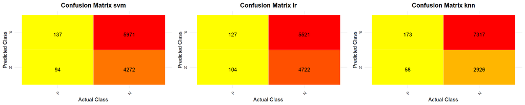

```r
confuse_df <- final_result %>% select("Model", "TP.1", "FN.1", "FP.1", "TN.1")
colnames(confuse_df) <- c("model", "TP", "FN", "FP", "TN")
baseline <- c('svm', 'lr', 'knn')
baseline_df <- filter(confuse_df, model %in% baseline)


plots <- lapply(unique(baseline_df$model), plot_confusion_matrix)
grid.arrange(
  arrangeGrob( plots[[2]], plots[[3]], plots[[1]], ncol = 3))
```

The first thing we notice is that these models are most frequently predicting True Negatives, meaning they are good at predicting who does not have hidden hypoxemia. Their specificity and sensitivity are better but still not particularly good. CatBoost has the best specificity but the worst sensitivity. The other 3 models are largely similar to each other. We used further metrics and visual tools to find our best model.

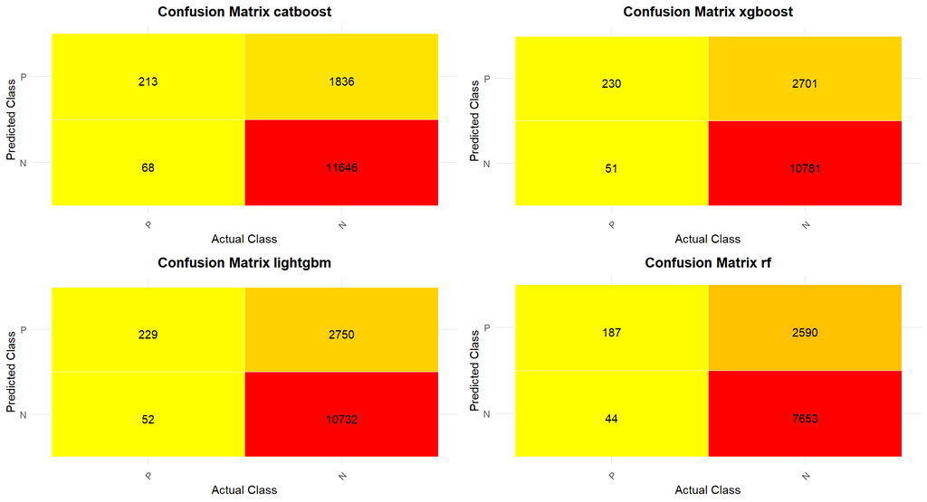

```r
trees <- c('catboost', 'lightgbm', 'rf', 'xgboost')
tree_df <- filter(confuse_df, model %in% trees)


plots <- lapply(unique(tree_df$model), plot_confusion_matrix)
grid.arrange(
  arrangeGrob(plots[[4]], plots[[2]], plots[[3]], plots[[1]], ncol = 2, nrow = 2))
```

The chart below depicts the runtime of each model. It can be observed that CatBoost has the longest training duration, yet correspondingly, it also boasts the best predictive performance. Both XGBoost and LightGBM strike a good balance between computation time and performance.

```
## Defaulting to continuous.
```

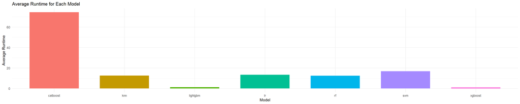

```r
p <- ggplot(final_result, aes(x=Model, y=runtime, fill=Model)) +
  geom_bar(stat="identity", width=0.7) +
  labs(title="Average Runtime for Each Model",
       x="Model",
       y="Average Runtime") +
  theme_minimal() +
  theme(legend.position="none")
print(p)
```

From the results so far the best performing models are LightGBM and XGBoost which are fast and have good recall and CatBoost which is slower but performs better on all the metrics other than recall. It is not clear which of these models is most useful. To decide this we will need a comparison which is suitable for our question and allows direct comparison of the models. This will be accomplished via a lift graph.

Consider sorting all the samples by their predicted probability of having positive class, then going through these and at each sample taking the ratio of cumulative number of positive samples found to the expected number from randomly guessing. This therefore shows model performance vs random guessing.

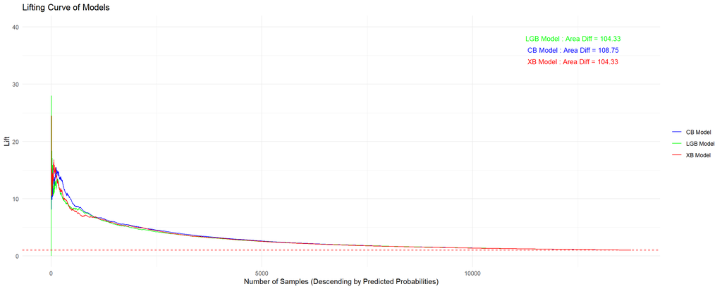

```r
lifting_curve_combined <- function(results_list, titles){
  data_for_plot <- data.frame()
  area_diff_list <- list()

  for (i in 1:length(results_list)) {
    test_target_numeric <- as.numeric(as.character(results_list[[i]]$true_test))
    predicted_probs <- results_list[[i]]$pred_test

    tmp <- data.frame(test_target_numeric, predicted_probs) %>%
      arrange(desc(predicted_probs)) %>%
      mutate(cumulative_actuals = cumsum(test_target_numeric),
             expected_positives = row_number() * (sum(test_target_numeric) / n()),
             lift = cumulative_actuals / expected_positives,
             model = titles[i],
             x = seq_len(n())) # <-- Add this line

    area_curve = sum(tmp$cumulative_actuals) / nrow(tmp)
    area_line = sum(tmp$expected_positives) / nrow(tmp)
    diff_area = area_curve - area_line
    area_diff_list[[titles[i]]] <- diff_area

    data_for_plot <- rbind(data_for_plot, tmp)
  }

  plot <- ggplot(data_for_plot, aes(x = x, y = lift, color = model)) +
    geom_line() +
    geom_hline(yintercept = 1, color = "red", linetype = "dashed") +
    labs(title = "Lifting Curve of Models",
         x = "Number of Samples (Descending by Predicted Probabilities)",
         y = "Lift") +
    theme_minimal() +
    scale_color_manual(values = c("blue", "green", "red")) +
    theme(legend.title = element_blank()) +
    ylim(0,40)  # 设置y轴范围

  for (i in 1:length(titles)) {
    plot <- plot + annotate("text", x = nrow(data_for_plot) * 0.3, y = 38 - (i - 1) * 2,
                            label = paste(titles[i], ": Area Diff =", round(area_diff_list[[titles[i]]], 2)),
                            color = c("green", "blue", "red")[i], size = 3.5)
  }

  return(plot)
}

results_list <- list(
  result_lgt = list(true_test = result_lgb$true_test, pred_test = result_lgb$pred_prob),
  result_cb = list(true_test = result_cb$true_test, pred_test = result_cb$pred_prob),
  result_xb = list(true_test = result_xb$true_test, pred_test = result_xb$pred_prob)
)

titles <- c("LGB Model", "CB Model", "XB Model")

plot_combined <- lifting_curve_combined(results_list, titles)
print(plot_combined)
```

This is particularly useful in a medical context since we want to limit unnecessary follow up testing. This shows the effectiveness of the models when using only a subset of their most confident predictions. We can see that CatBoost performs better than the other two models with a small to moderate number of samples and is therefore the best model for our purposes.

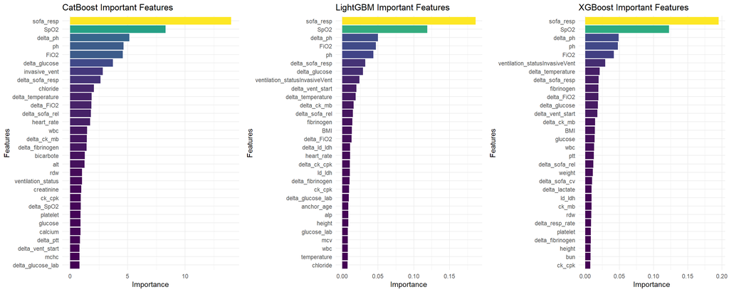

```r
importance <- result_cb$model$feature_importances
sorted_indices <- order(importance, decreasing = TRUE)
sorted_importance <- importance[sorted_indices]
sorted_features <- colnames(train_vars)[sorted_indices]
top_30_importance <- sorted_importance[1:30]
top_30_features <- sorted_features[1:30]
df_CatBoost <- data.frame(Features = top_30_features, Importance = top_30_importance)

# Select the top 30 features
top_30_importance <- lgb.importance(result_lgb$model)$Gain[1:30]
top_30_features <- lgb.importance(result_lgb$model)$Feature[1:30]
df_LightGBM <- data.frame(Features = top_30_features, Importance = top_30_importance)

top_30_importance <- xgb.importance(model = result_xb$model)$Gain[1:30]
top_30_features <- xgb.importance(model = result_xb$model)$Feature[1:30]
df_XGBoost <- data.frame(Features = top_30_features, Importance = top_30_importance)

plot_importance <- function(df, title) {
  ggplot(df, aes(x = reorder(Features, Importance), y = Importance, fill = Importance)) +
    geom_bar(stat = "identity") +
    coord_flip() +
    scale_fill_viridis_c() +
    labs(title = title, x = "Features", y = "Importance") +
    theme_minimal() +
    theme(legend.position = "none")
}

plot_cb <- plot_importance(df_CatBoost, "CatBoost Important Features")
plot_lgt <- plot_importance(df_LightGBM, "LightGBM Important Features")
plot_xb <- plot_importance(df_XGBoost, "XGBoost Important Features")

grid.arrange(plot_cb, plot_lgt, plot_xb, ncol = 3)
```

### 6. Discussion and Conclusion

#### Reflection

1. A variety of preprocessing methods should be explored. While we have tested under-sampling and the SMOTE method, the results indicate that the efficacy of SMOTE is limited. We might need to explore other balancing techniques to enhance the baseline model’s performance, as its predictions currently resemble random guessing. Additionally, we can leverage inherent functions within tree-based models that address unbalanced datasets. These functions directly assign weights to different labels. For instance, given the original class ratio of 50:1 in this dataset, we can assign weights of 1:50. This increases the loss when the minor class prediction fails, potentially yielding improved results.
2. Concerning the final model, since all boosting methods have demonstrated promising results in predicting hidden hypoxemia, we could further integrate them. By creating a voting system, akin to the random forest approach, and using these models to determine the final outcome, we can enhance the predictive capability. To combine the outputs produced by these classifiers, a majority voting scheme can be applied.(Rokach, 2010)
3. Regarding feature importance, a more insightful approach would be to ascertain the directional effect of each feature. This allows us to understand how increasing or decreasing a particular feature influences the probability of hidden hypoxemia. This can be achieved using SHAP values. SHAP (SHapley Additive exPlanation) values attribute to each feature the change in the expected model prediction when conditioning on that feature(Lundberg and Lee, 2017). So that we could provide doctors with more constructive feedback.
4. Much of our analysis is picking up on respiratory variables which predict hypoxemia generally. If we could avoid this confounding effect we could get a better idea of the factors genuinely tied to pulse oximetry inaccuracies which could help to address the problem of hidden hypoxemia at its root. Pursuing such questions would likely require far more domain knowledge than we possess.

#### Conclusion

In conclusion, tree-based models proved to be far better for this than KNN, LR, or SVM. The RF was better than the first three but worse than other tree-based models. Of the remaining three XGB and LightGBM were much faster than CatBoost and had better recall but CatBoost was better in precision and in combined metrics like F1 and accuracy. To decide between these we relied on a lift graph which suggested that CatBoost is the best choice for our question.

Furthermore, we recommend that medical professionals pay close attention to respiratory indicators such as blood pH and those on respirators and understand that they can be a warning sign of hidden hypoxemia even if SpO2 scores are fine.

### 7. Reference

Alam, Md.Z., Rahman, M. Saifur and Rahman, M. Sohel (2019) ‘A Random Forest based predictor for medical data classification using feature ranking’, Informatics in Medicine Unlocked, 15, p. 100180. Available at: https://doi.org/10.1016/j.imu.2019.100180.

Al-Sarem, M. et al. (2021) ‘Feature Selection and Classification Using CatBoost Method for Improving the Performance of Predicting Parkinson’s Disease’, in F. Saeed et al. (eds) Advances on Smart and Soft Computing. Singapore: Springer (Advances in Intelligent Systems and Computing), pp. 189–199. Available at: https://doi.org/10.1007/978-981-15-6048-4_17.

Cervantes, J. et al. (2020) ‘A comprehensive survey on support vector machine classification: Applications, challenges and trends’, Neurocomputing, 408, pp. 189–215. Available at: https://doi.org/10.1016/j.neucom.2019.10.118.

Chen, T. and Guestrin, C. (2016) ‘XGBoost: A Scalable Tree Boosting System’, in Proceedings of the 22nd ACM SIGKDD International Conference on Knowledge Discovery and Data Mining. New York, NY, USA: Association for Computing Machinery (KDD ’16), pp. 785–794. Available at: https://doi.org/10.1145/2939672.2939785.

Dimitrakopoulos, G.N. et al. (2018) ‘Pathway analysis using XGBoost classification in Biomedical Data’, in Proceedings of the 10th Hellenic Conference on Artificial Intelligence. New York, NY, USA: Association for Computing Machinery (SETN ’18), pp. 1–6. Available at: https://doi.org/10.1145/3200947.3201029.

Lundberg, S.M. and Lee, S.-I. (2017) ‘A Unified Approach to Interpreting Model Predictions’, in Advances in Neural Information Processing Systems. Curran Associates, Inc. Available at: https://papers.nips.cc/paper_files/paper/2017/hash/8a20a8621978632d76c43dfd28b67767-Abstract.html (Accessed: 29 October 2023).

Matos, J.C.R.G. (2023) ‘Research Frameworks towards Health Equity’. Available at: https://repositorio-aberto.up.pt/handle/10216/150994 (Accessed: 28 October 2023).

Probst, P., Wright, M.N. and Boulesteix, A.-L. (2019) ‘Hyperparameters and tuning strategies for random forest’, WIREs Data Mining and Knowledge Discovery, 9(3), p. e1301. Available at: https://doi.org/10.1002/widm.1301.

Prokhorenkova, L. et al. (2018) ‘CatBoost: unbiased boosting with categorical features’, in Advances in Neural Information Processing Systems. Curran Associates, Inc. Available at: https://papers.nips.cc/paper_files/paper/2018/hash/14491b756b3a51daac41c24863285549-Abstract.html (Accessed: 29 October 2023).

Rokach, L. (2010) ‘Ensemble-based classifiers’, Artificial Intelligence Review, 33(1), pp. 1–39. Available at: https://doi.org/10.1007/s10462-009-9124-7.

Tsien, C.L. et al. (1998) ‘Using Classification Tree and Logistic Regression Methods to Diagnose Myocardial Infarction’, in MEDINFO '98. IOS Press, pp. 493–497. Available at: https://doi.org/10.3233/978-1-60750-896-0-493.

Wang, D., Zhang, Y. and Zhao, Y. (2017) ‘LightGBM: An Effective miRNA Classification Method in Breast Cancer Patients’, in Proceedings of the 2017 International Conference on Computational Biology and Bioinformatics. New York, NY, USA: Association for Computing Machinery (ICCBB ’17), pp. 7–11. Available at: https://doi.org/10.1145/3155077.3155079.

Xing, W. and Bei, Y. (2020) ‘Medical Health Big Data Classification Based on KNN Classification Algorithm’, IEEE Access, 8, pp. 28808–28819. Available at: https://doi.org/10.1109/ACCESS.2019.2955754.

### 8. Contribution

jewa0140 - 16%: I was responsible for the CatBoost model. I also focused on the underlying reasons for our ML on this dataset and ensuring that our models and metrics contributed usefully to the overall aim, in this vein I did the lift graphs and pushed for them to be used as a primary metric of comparison since they are good for demonstrating how effective the models will be in a clinical context. I worked to make sure that the project was proceeding in a statistically valid way and in a direction which was useful for our research aim. I also answered most of the questions during our presentation.

ztao0063 - 16%: I am responsible for managing the progress of the project. I regularly convene meetings with all team members to advance the project, decide on individual responsibilities, choose preprocessing methods, and select the models. Additionally, I’ve written the majority of the code, which includes the preprocessing methods, evaluation for all models, LightGBM, subsequent variable importance coding, and integration of the code from all team members. Furthermore, I determined the overall framework of the report and made appropriate modifications to the sections written by others.

ggol9181 - 15%: I was responsible for building the XGBoost model, researching current best practices for using this model. I also experimented with other hyperparameter tuning frameworks like Bayesian optimisation and Random Search to test whether they elicited better results. Whilst the results were promising ultimately we decided as a group to be consistent in our hyperparameter tuning methodology and use grid search. I created the tables in our report, using the kable and kableExtra package. I pushed for the use of confusion matrices to visualise our results and was integral in using these to make sense of our models as I often find this more informative than a number from a metric. During the presentation I created the introducing our model slide, the results slide, the hyperparameter slide and the 2 confusion matrices slides. Overall I feel I made a valuable contribution to this team.

shdi0195 - 14%: I was responsible for the construction and tuning of the random forest model. I experimented with different preprocessing, balancing, and missing value imputation methods to find the optimal ones suited for the random forest model. I was also responsible for the correlation plot used in the presentation.

yyua0659 - 14%: I was responsible for building KNN model, visualizaing comparison of sensitivity, specificity and runtime of all models. In the presentation, I covered data description, IDA and comparison of runtime part. In the final report, I set the overall framework, wrote most of work including the overview, data preprocessing and classification algorithms used part, and modified and added references. During the communication, I solved problems in a timely manner and coordinated assignments for current tasks.

qiyu0241 - 13%: I was responsible for building the logistic regression model , visualizing missing value, the visualization and interpretation of feature engineering. Additionally, I interpret the results of Support Vector Machine and logistic regression in the final report. During the presentation, I focused on the feature engineering. When producing the presentation videl, I was responsible for the recording work, the organization of the overall recording precess and the post-production video editing.

liyu0238 - 12%: I was responsible for the SVM model and I tried using the 1:10 ratio data preprocessing approach, but it didn’t turn out well, so with the code given by Zerui for handling imbalance and missing values. The SVM model has small improvement by tuning the parameter even though the SVM model has a slightly lower accuracy value for this dataset as compared to the tree model, and then there is the visualization method of PCA to deal with it. During the Presentation, I am in charge of define balance data method.